# Human Activity Recognition

Suman Machado

Friday, January 29, 2016

# Executive Summary

Human activity recognition research traditional focused on discriminating between different activities. This assignment uses the weight lifting dataset and the goal is to determine “how well” the activity is performed.

The data for this project come from this source: http://groupware.les.inf.puc-rio.br/har. The collected data is from accelerometers on the belt, forearm, arm, and dumbell of 6 participants. They were asked to perform barbell lifts correctly and incorrectly in 5 different ways. The goal of this project is to predict the manner in which they did the exercises using the “classe” variable in the training set.

# Loading and summarizing the data

These are the dimensions of the dataset and a summary of the “classe” variable

```
## [1] 19622   160
```

```
##    A    B    C    D    E
## 5580 3797 3422 3216 3607
```

# Data preparation

On viewing a sample of the data the first 7 columns do not seem relevant for predicting “classe”. Since there’s no intention of performing a time series analysis, variables with timestamp can be removed. There were also many columns found with no data in them which were removed.

Exploring the data - a pairwise scatterplot matrix of 3 variables.

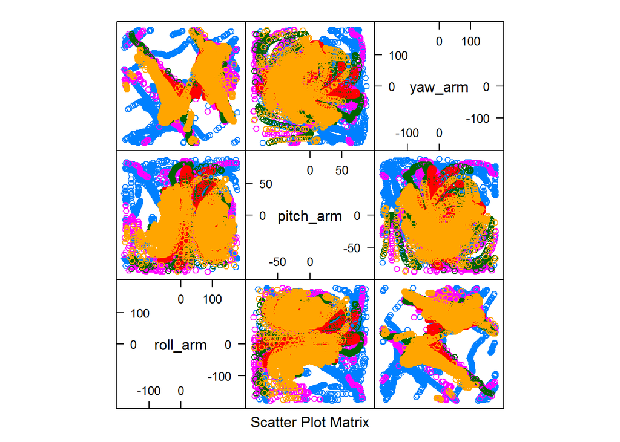

Plotting a couple variables separately to explore the data further.

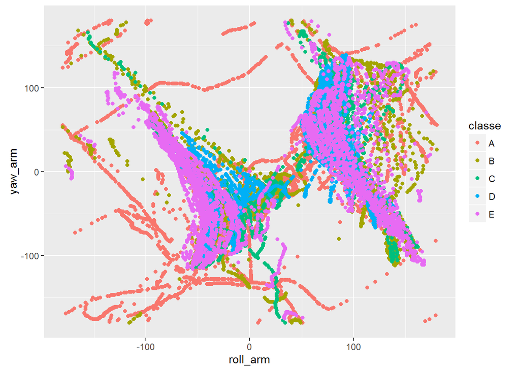

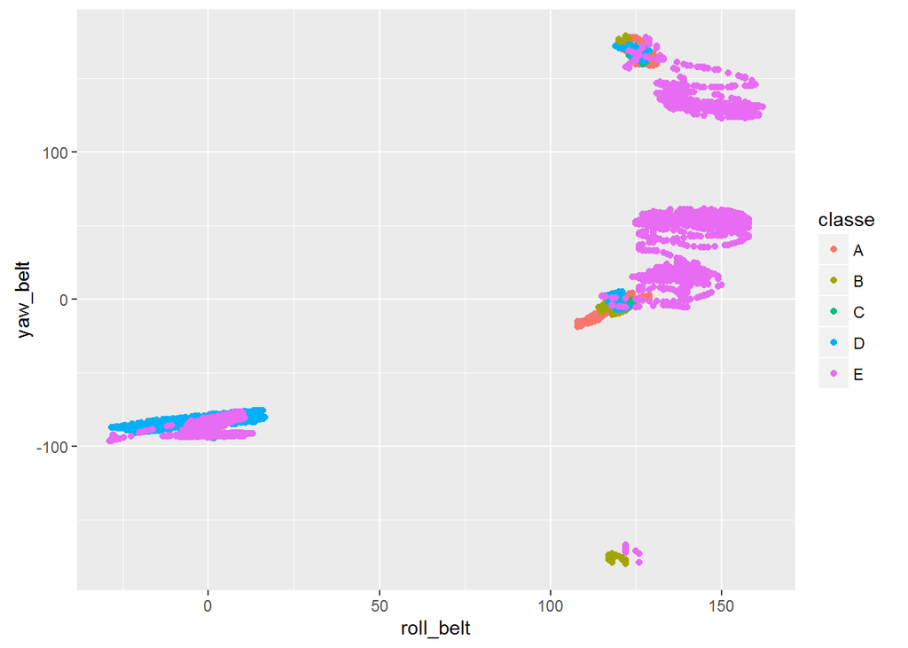

There are too many variables in the data to study them individually and the plots did not help find the most promising predictors.

# Data splitting

The data set is split into train and test sets using createDataPartition which balances the split thereby preserving the overall class distribution of the data. The models are then built on the training set and the test set is used for prediction.

# Principal Component Analysis

Since there are a large number of predictors, as a first step PCA was used to reduce the number of predictors and pick a combination that captures the most information possible.

```
## Created from 13737 samples and 52 variables
##
## Pre-processing:
##   - Box-Cox transformation (2)
##   - centered (52)
##   - ignored (0)
##   - principal component signal extraction (52)
##   - scaled (52)
##
## Lambda estimates for Box-Cox transformation:
## 2, 0.9
## PCA needed 12 components to capture 80 percent of the variance
```

```
## Confusion Matrix and Statistics
##
##           Reference
## Prediction    A    B    C    D    E
##          A 1635   13   17    6    3
##          B   30 1072   29    3    5
##          C   14   21  971   16    4
##          D   12    4   38  908    2
##          E    0   12   10   12 1048
##
## Overall Statistics
##
##                Accuracy : 0.9573
##                  95% CI : (0.9519, 0.9624)
##     No Information Rate : 0.2873
##     P-Value [Acc > NIR] : < 2.2e-16
##
##                   Kappa : 0.946
##  Mcnemar's Test P-Value : 0.0001252
##
## Statistics by Class:
##
##                      Class: A Class: B Class: C Class: D Class: E
## Sensitivity            0.9669   0.9554   0.9117   0.9608   0.9868
## Specificity            0.9907   0.9859   0.9886   0.9887   0.9930
## Pos Pred Value         0.9767   0.9412   0.9464   0.9419   0.9686
## Neg Pred Value         0.9867   0.9895   0.9807   0.9925   0.9971
## Prevalence             0.2873   0.1907   0.1810   0.1606   0.1805
## Detection Rate         0.2778   0.1822   0.1650   0.1543   0.1781
## Detection Prevalence   0.2845   0.1935   0.1743   0.1638   0.1839
## Balanced Accuracy      0.9788   0.9707   0.9502   0.9748   0.9899
```

At a threshold of 80% there were 12 principal components selected. The Confusion Matrix shows an accuracy of 95% which is good but maybe using random forests will result in better accuracy.

# Random Forests

The random forest model fits a number of decision tree classifiers on various sub-samples of the dataset and uses averaging to improve the predictive accuracy and control over-fitting

```
##
## Call:
##  randomForest(formula = classe ~ ., data = training)
##                Type of random forest: classification
##                      Number of trees: 500
## No. of variables tried at each split: 7
##
##         OOB estimate of  error rate: 0.47%
## Confusion matrix:
##      A    B    C    D    E  class.error
## A 3905    1    0    0    0 0.0002560164
## B   10 2641    7    0    0 0.0063957863
## C    0   16 2377    3    0 0.0079298831
## D    0    0   14 2235    3 0.0075488455
## E    0    1    0   10 2514 0.0043564356
```

Here’s a look at the variables that were important.

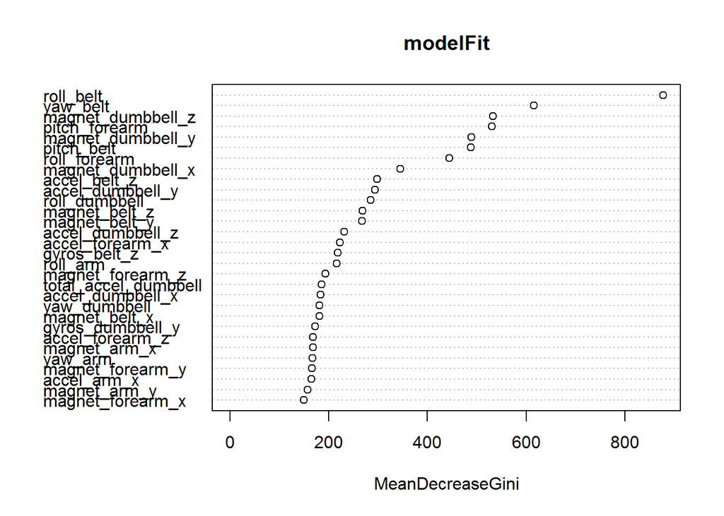

Checking the accuracy of the model using the testing data:

```
##
## prediction    A    B    C    D    E
##          A 1672    4    0    0    0
##          B    1 1134    6    0    0
##          C    1    1 1014   17    0
##          D    0    0    6  947    4
##          E    0    0    0    0 1078
```

```
## [1] 0.9932031
```

At an accuracy of 99% the random forest model performed better than using the principal components.

# Predicting the test cases

```
##  1  2  3  4  5  6  7  8  9 10 11 12 13 14 15 16 17 18 19 20
##  B  A  B  A  A  E  D  B  A  A  B  C  B  A  E  E  A  B  B  B
## Levels: A B C D E
```